# ILSE: Model catalog

This report tallies the models that you have provided to the workshop collective so far. For frequency counts across studies consult [Model Counts](http://htmlpreview.github.io/?https://github.com/IALSA/IALSA-2015-Portland/blob/master/reports/counts.html) report. For correlations between random terms in bivariate models across all studies consult [Model Essentials](http://htmlpreview.github.io/?https://github.com/IALSA/IALSA-2015-Portland/blob/master/reports/essentials.html)

This report **AIMS** to accomplish two things:  
1. Help you identify and **correct the errors** in the filenames so that your models can be processed properly  
2. Help you identify what models should be added to **maximize replicability** effect across studies

## Introduction and Rationale

Your study

```
[1] "ilse"
```

has provided us with the total number of

```
57
```

models, using univariate and bivariate specifications:

```
b1 u0 u1 u2
47  4  6  .
```

To remind you, **model_number** (*b1, u0, u1, u2*) refers to the model specification, as shown in the figure below. The first letter (*b* or *u*) indicates whether the models specifies a single outcome (*u* for *univariate*) or two outcomes (*b* for *bivariate*), while the number (e.g. u*0*, u*1*, u*2*) indicates the highest random term on the first level.

The figure below (next section) shows the proper naming convention for the models you estimated in your study. Please use it to correct the names of some of your models. Our scripts rely on this naming convention for the key information about the model (most importantly, names of the constructs and measures). Therefore, it is of utmost importance that these rules are followed. **If named incorrectly, models might not be used in the collective analysis**.

Some mistakes could be corrected automatically. Other, however, require *specifically* your attention. To illustrate, consider a cognitive construct *knowledge*. We’ve encountered entries *knowlegde*, *knowledg*, and *knwoledge*; it is obvious that these three spellings meant to say *knowledge*, and we program the script to correct it automatically. On the other hand, consider a physical construct *pulmonary*, which has two similarly spelled measures, *fev* and *fvc*. When we see a measure of *pulmonary* called *fevc*, we don’t know how to interpret it, it could be a misspelling of either one. This is where we need your help.

## Naming rules

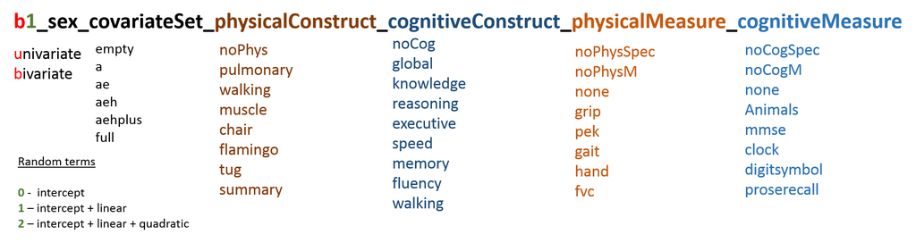

The name of the file **must always contain 7 components** separated by an underscore ( _ ) symbol. The figure above shows the anatomy of a protypical file name with examples of particular values. For example, a bivariate model with random intercepts and slopes (b1), fitted to subsample of females, using age and height as predictors on the second level, and pairing a *pulmonary* measure *fvc* with a *reasoning* measure *block* will have the name

```
b1_female_ae_pulmonary_reasoning_fvc_block
```

### Filename components

From left to right, the components of filename are:

1. Model number (*e.g.* b1, u0) - specification(u, b) and highest random term (0,1,2)
2. Sex (*e.g.* male, female) - model fitted using this subset of data
3. covariateSet - a set of predictors entered into the model on the second level:
   - **empty** : no covariate included into the model
   - **a** : age is entered as a baseline measure, second level
   - **ae** : age + education
   - **aeh** : age + education + height
   - **aehplus**: age + education + height + diabetes + smoking history + cardiovascular
   - **full** : all covariates availible in the study (will be different across studies)
4. Physical Construct (*e.g.* pulmonary, muscle) - general physical function that can have a number of specific operationalizations or measurements.
5. Cognitive Construct (*e.g.* reasoning, memory) - general cognitive function that can have a number of specific operationalizations or measurements.
6. Physical Measure (e.g. pek, grip ) - a specific way to operationalize the measurement of a physical construct
7. Cognitive Measure (e.g. block, digitspan ) - a specific way to operationalize the measurement of a cognitive construct

### Additional rules

- Construct and Measure names cannot be the same  
  For example, such file names as `u1_male_eah_pulmonary_noCog_pulmonary_noCogSpec` should be avoided.
- In univariate models, the absence of a modeling term must be explicit:

`u1_male_aeh_pulmonary_noCog_pek_noCogSpec` instead of  
`u1_male_aeh_pulmonary_pek` The exact spelling of the explicit absence is not very important: *noPhys*, *nophys*, *noghys* will work just fine and will be caught by an automatic filter.

## Errors of omission

The most common mistake is omitting some of the 7 elements in the name of the output file. The following files need to be renamed so that our scripts can understand what constructs and measures were used in your models:

```
All your models were named properly
```

After removing incorrectly named files, there are

```
57
```

models, which output files contains all 7 components. We have corrected the obvious typos, but some names (of constructs and measures) require your attention.

# Simple Counts

In this section, **model specification (columns)** are cross-tabulated with **constructs or measures (rows)**, displaying the number of valid models in each category.

## Physical constructs

```
< table of extent 0 x 4 >
```

## Physical measures

```
         b1 u0 u1 u2
  muscle 12 2  .  .
  tug    35 2  6  .
```

## Cognitive constructs

```
< table of extent 0 x 4 >
```

## Cognitive measures

```
            b1 u0 u1 u2
  fluency   7  .  .  .
  knowledge 8  .  .  .
  reasoning 24 .  .  .
  speed     8  .  .  .
  univar    .  4  6  .
```

# BIVARIATE MODELS

In this section, **constructs (columns)** are cross-tabulated with **measures (rows)** that opeationalize them in the models. Each non-blank element in a column indicates a unique **measure (row)** of the **construct (column)**. The numeric value shows how many different versions of this model used this specific pair of construct and measure: model may differ on the subgroup (male, female), and the set of covariates (empty, a, ae, aeh, aehplus, full).

## Physical

Physical **constructs** (columns) by physical **measures** (rows) in BIVARIATE models

```
< table of extent 2 x 0 >
```

## Cognitive

Cognitive **constructs** (columns) by cognitive **measures** (rows) in BIVARIATE models

```
< table of extent 4 x 0 >
```

## Constructs

Number of models with the following **physical constructs** (columns) and **cognitive constructs** (rows)

```
< table of extent 0 x 0 >
```

## Phys.Constructs

Number of models with the following **physical constructs** (columns) and **cognitive measures** (rows)

```
< table of extent 4 x 0 >
```

## Cog.Constructs

Number of models with the following **physical measure** (columns) and **cognitive constructs** (rows)

```
< table of extent 0 x 2 >
```

## Measures

Number of models with the following **physical measures** (columns) and **cognitive measures** (rows)

```
            muscle tug
  fluency   2      5
  knowledge 2      6
  reasoning 6      18
  speed     2      6
```

# UNIVARIATE MODELS

In this section, **constructs (columns)** are cross-tabulated with **measures (rows)** that opeationalize them in the models. Each non-blank element in a column indicates a unique **measure (row)** of the **construct (column)**. The numeric value counts the different versions of the model (sex, covariates) that used this specific pair of construct and measure.

## Physical

Physical constructs (columns) by physical measures (rows) in UNIVARIATE models

```
b1 muscle
   tug
u0 muscle
   tug
u1 muscle
   tug
u2 muscle
   tug
```

## Cognitive

Cognitive constructs (columns) by cognitive measures (rows) in UNIVARIATE models

```
b1 univar
u0 univar
u1 univar
u2 univar
```

# List of models

## b1

| model tag | sex | predictor set | physical construct | cognitive construct | physical measure | cognitive measure | file name |
| --- | --- | --- | --- | --- | --- | --- | --- |
| b1 | female | aehplus | NA | NA | muscle | fluency | b1_female_aehplus_muscle_fluency_grip_verbalfluencytest.out |
| b1 | male | aehplus | NA | NA | muscle | fluency | b1_male_aehplus_muscle_fluency_grip_verbalfluencytest.out |
| b1 | female | aeh | NA | NA | tug | fluency | b1_female_aeh_tug_fluency_tug_verbalfluencytest.out |
| b1 | female | aehplus | NA | NA | tug | fluency | b1_female_aehplus_tug_fluency_tug_verbalfluencytest.out |
| b1 | female | a | NA | NA | tug | fluency | b1_female_age_tug_fluency_tug_verbalfluencytest.out |
| b1 | male | aeh | NA | NA | tug | fluency | b1_male_aeh_tug_fluency_tug_verbalfluencytest.out |
| b1 | male | a | NA | NA | tug | fluency | b1_male_age_tug_fluency_tug_verbalfluencytest.out |
| b1 | female | aehplus | NA | NA | muscle | knowledge | b1_female_aehplus_muscle_knowledge_grip_waisgeneralknowledge.out |
| b1 | male | aehplus | NA | NA | muscle | knowledge | b1_male_aehplus_muscle_knowledge_grip_waisgeneralknowledge.out |
| b1 | female | aeh | NA | NA | tug | knowledge | b1_female_aeh_tug_knowledge_tug_waisgeneralknowledge.out |
| b1 | female | aehplus | NA | NA | tug | knowledge | b1_female_aehplus_tug_knowledge_tug_waisgeneralknowledge.out |
| b1 | female | a | NA | NA | tug | knowledge | b1_female_age_tug_knowledge_tug_waisgeneralknowledge.out |
| b1 | male | aeh | NA | NA | tug | knowledge | b1_male_aeh_tug_knowledge_tug_waisgeneralknowledge.out |
| b1 | male | aehplus | NA | NA | tug | knowledge | b1_male_aehplus_tug_knowledge_tug_waisgeneralknowledge.out |
| b1 | male | a | NA | NA | tug | knowledge | b1_male_age_tug_knowledge_tug_waisgeneralknowledge.out |
| b1 | female | aehplus | NA | NA | muscle | reasoning | b1_female_aehplus_muscle_reasoning_grip_lpsspacialability.out |
| b1 | female | aehplus | NA | NA | muscle | reasoning | b1_female_aehplus_muscle_reasoning_grip_waispicturecompletion.out |
| b1 | female | aehplus | NA | NA | muscle | reasoning | b1_female_aehplus_muscle_reasoning_nophysspec_waisblockdesign.out |
| b1 | male | aehplus | NA | NA | muscle | reasoning | b1_male_aehplus_muscle_reasoning_grip_lpsspatialability.out |
| b1 | male | aehplus | NA | NA | muscle | reasoning | b1_male_aehplus_muscle_reasoning_grip_waispicturecompletion.out |
| b1 | male | aehplus | NA | NA | muscle | reasoning | b1_male_aehplus_muscle_reasoning_nophysspec_waisblockdesign.out |
| b1 | female | aeh | NA | NA | tug | reasoning | b1_female_aeh_tug_reasoning_tug_lpsspacialability.out |
| b1 | female | aeh | NA | NA | tug | reasoning | b1_female_aeh_tug_reasoning_tug_waisblockdesign.out |
| b1 | female | aeh | NA | NA | tug | reasoning | b1_female_aeh_tug_reasoning_tug_waispicturecompletion.out |
| b1 | female | aehplus | NA | NA | tug | reasoning | b1_female_aehplus_tug_reasoning_tug_lpsspacialability.out |
| b1 | female | aehplus | NA | NA | tug | reasoning | b1_female_aehplus_tug_reasoning_tug_waisblockdesign.out |
| b1 | female | aehplus | NA | NA | tug | reasoning | b1_female_aehplus_tug_reasoning_tug_waispicturecompletion.out |
| b1 | female | a | NA | NA | tug | reasoning | b1_female_age_tug_reasoning_tug_lpsspacialability.out |
| b1 | female | a | NA | NA | tug | reasoning | b1_female_age_tug_reasoning_tug_waisblockdesign.out |
| b1 | female | a | NA | NA | tug | reasoning | b1_female_age_tug_reasoning_tug_waispicturecompletion.out |
| b1 | male | aeh | NA | NA | tug | reasoning | b1_male_aeh_tug_reasoning_tug_lpsspacialability.out |
| b1 | male | aeh | NA | NA | tug | reasoning | b1_male_aeh_tug_reasoning_tug_waisblockdesign.out |
| b1 | male | aeh | NA | NA | tug | reasoning | b1_male_aeh_tug_reasoning_tug_waispicturecompletion.out |
| b1 | male | aehplus | NA | NA | tug | reasoning | b1_male_aehplus_tug_reasoning_tug_lpsspacialability.out |
| b1 | male | aehplus | NA | NA | tug | reasoning | b1_male_aehplus_tug_reasoning_tug_waisblockdesign.out |
| b1 | male | aehplus | NA | NA | tug | reasoning | b1_male_aehplus_tug_reasoning_tug_waispicturecompletion.out |
| b1 | male | a | NA | NA | tug | reasoning | b1_male_age_tug_reasoning_tug_lpsspacialability.out |
| b1 | male | a | NA | NA | tug | reasoning | b1_male_age_tug_reasoning_tug_waisblockdesign.out |
| b1 | male | a | NA | NA | tug | reasoning | b1_male_age_tug_reasoning_tug_waispicturecompletion.out |
| b1 | female | aehplus | NA | NA | muscle | speed | b1_female_aehplus_muscle_speed_grip_digitsymbolsubstitutiontest.out |
| b1 | male | aehplus | NA | NA | muscle | speed | b1_male_aehplus_muscle_speed_grip_digitsymbolsubstitutiontest.out |
| b1 | female | aeh | NA | NA | tug | speed | b1_female_aeh_tug_speed_tug_waisdigitsymbolsubstitutiontest.out |
| b1 | female | aehplus | NA | NA | tug | speed | b1_female_aehplus_tug_speed_tug_waisdigitsymbolsubstitution.out |
| b1 | female | a | NA | NA | tug | speed | b1_female_age_tug_speed_tug_digitsymbolsubstitutiontest.out |
| b1 | male | aeh | NA | NA | tug | speed | b1_male_aeh_tug_speed_tug_waisdigitsymbolsubstitutiontest.out |
| b1 | male | aehplus | NA | NA | tug | speed | b1_male_aehplus_tug_speed_tug_waisdigitsymbolsubstitution.out |
| b1 | male | a | NA | NA | tug | speed | b1_male_age_tug_speed_tug_digitsymbolsubstitutiontest.out |

## u0

| model tag | sex | predictor set | physical construct | cognitive construct | physical measure | cognitive measure | file name |
| --- | --- | --- | --- | --- | --- | --- | --- |
| u0 | female | 0 | NA | NA | tug | univar | u0_female_empty_tug_nocog_tug_nocogspec.out |
| u0 | male | 0 | NA | NA | tug | univar | u0_male_empty_tug_nocog_tug_nocogspec.out |
| u0 | female | 0 | NA | NA | muscle | univar | u0_female_empty_muscle_nocog_nophysspec_nocogspec.out |
| u0 | male | 0 | NA | NA | muscle | univar | u0_male_empty_muscle_nocog_nophysspec_nocogspec.out |

## u1

| model tag | sex | predictor set | physical construct | cognitive construct | physical measure | cognitive measure | file name |
| --- | --- | --- | --- | --- | --- | --- | --- |
| u1 | female | aeh | NA | NA | tug | univar | u1_female_aeh_tug_nocog_tug_nocogspec.out |
| u1 | female | aehplus | NA | NA | tug | univar | u1_female_aehplus_tug_nocog_tug_nocogspec.out |
| u1 | female | a | NA | NA | tug | univar | u1_female_age_tug_nocog_tug_nocogspec.out |
| u1 | male | aeh | NA | NA | tug | univar | u1_male_aeh_tug_nocog_tug_nocogspec.out |
| u1 | male | aehplus | NA | NA | tug | univar | u1_male_aehplus_tug_nocog_tug_nocogspec.out |
| u1 | male | a | NA | NA | tug | univar | u1_male_age_tug_nocog_tug_nocogspec.out |

# Session Information

For the sake of documentation and reproducibility, the current report was rendered on a system using the following software.

```
Report rendered by koval_000 at 2015-12-15, 15:06 -0800
```